# First analysis

Arvid Mikkers

# Packages

```r
library(tidyverse) # for data manipulation and plots
library(PerformanceAnalytics) # for correlation plots
library(thematicmaps)# for maps
library(corrr) # for network graphs of variables
library(ggrepel) # for names in graphs
library(glmnet) # for lasso
library(car) # to check for multicollinearity
library(caret) # for machine learning
```

# Data

```r
d1 <- read.csv2("../Sourcedata/Analysis/Datafile.csv")
str(d1)
```

```
'data.frame':   374 obs. of  29 variables:
 $ X                                   : int  1 2 3 4 5 6 7 8 9 10 ...
 $ LEtotalpop                          : num  82.5 80.9 83.2 82 81 82.8 82.7 81.7 79.7 81.8 ...
 $ LEwomen                             : num  85 81.9 85.7 84.1 83.1 84.6 84.4 83.6 81.6 83.3 ...
 $ LEmen                               : num  80 79.8 80.8 79.9 78.9 81.1 80.9 79.7 77.7 80.3 ...
 $ Gemeente                            : Factor w/ 374 levels "'s-Hertogenbosch",..: 2 3 4 5 6 7 8 9 10 11 ...
 $ Gescheiden_32                       : num  8.2 5.3 7.7 6.1 7.5 7.2 8.8 11 9.8 11.2 ...
 $ TotaalMetMigratieachtergrond_44     : num  5.9 5.5 18.1 11 4 13.6 19.3 21.6 24.9 40 ...
 $ Bevolkingsdichtheid_57              : int  91 259 1555 279 274 2270 1150 974 1076 1533 ...
 $ GemiddeldeHuishoudensgrootte_89     : num  2.26 2.65 2.41 2.35 2.39 2.46 2.43 2.1 2.24 2.38 ...
 $ Woningdichtheid_93                  : int  40 100 640 122 117 935 470 456 482 617 ...
 $ Koopwoningen_94                     : num  71.1 71.7 63.1 69.4 63.3 60.1 67.3 57.7 54.6 63.8 ...
 $ GemiddeldeWoningwaarde_99           : int  218 239 269 185 159 194 248 183 151 181 ...
 $ AfstandTotZiekenhuis_216            : num  11.5 11.8 9.7 14.5 15.7 8.5 6.3 4 3.7 4.4 ...
 $ TotaleBevolking_1                   : int  25243 13038 31299 26912 28007 19955 24985 107615 72425 198145 ...
 $ k_80JaarOfOuder_21                  : num  5.6 3.8 4.5 5.2 4 4.9 3.8 4.1 4.4 2 ...
 $ k_80JaarOfOuder_12                  : int  1408 490 1398 1397 1125 985 944 4457 3192 4009 ...
 $ RegioS                              : Factor w/ 374 levels "GM0003","GM0005",..: 315 224 122 61 21 161 197 123 41 12 ...
 $ GemiddeldGestandaardiseerdInkomen_41: int  23000 23700 25000 23500 20900 22500 24800 21500 20100 21000 ...
 $ InkomenTot120SociaalMinimum_13      : num  8.2 6.2 6.6 7.6 13 8.7 6.7 11.9 17.6 16 ...
 $ LagerOpgeleidenPercentage_5         : int  12 31 23 20 30 18 14 16 21 17 ...
 $ Percentage_eenpersoonshuishoudens   : num  26.4 23.3 27.9 27.9 28.7 ...
 $ gemeente                            : Factor w/ 374 levels "'s-Hertogenbosch",..: 2 3 4 5 6 7 8 9 10 11 ...
 $ ErvarenGezondheidGoedZeerGoed_1     : num  79.5 78.7 80.5 75.6 81.3 75.3 77.9 72.6 72.3 73.2 ...
 $ EenOfMeerLangdurigeAandoeningen_2   : num  33.5 24.9 31.3 35 35.9 33.4 32.1 36.2 38.2 34.1 ...
 $ NormaalGewicht_9                    : num  43.7 47.4 49 45.8 40.8 47.9 47.8 52.7 42.9 44 ...
 $ VoldoetAanFitnorm_14                : num  28.6 21.2 26.9 31.7 26.1 19.9 22.3 28.2 32 18.7 ...
 $ UrenMantelzorgPerWeek_19            : num  12.8 9.7 8 8.4 NA NA NA 8.7 10.2 16.4 ...
 $ WekelijkseSporters_16               : num  46.3 38.3 54.3 47.9 41.7 42.3 50.1 53.3 47.1 49.7 ...
 $ Totaal.bekende.CO2.uitstoot.2016    : int  NA NA NA 134297 159597 201343 117913 579053 571012 831527 ...
```

# Map

Since we are interested in the variation in life expectancy, we will first make a map.

To create maps we need polygon-data (data describing the polygons that constitute the map expressed in *x* and *y* coordinates). It is possible to buy this data from commercial parties, but more and more polygon data are published as open source data. For this thesis we used open source data from the CBS (central bureau of statitics in the Netherlands) and [Imergis](http://www.imergis.nl/asp/47.asp). Mark Klik (NZa) converted the polygon data to *csv* format.

For our first basic map, we need some data about the Netherlands. The polygon data from municipalities were previously saved as a *csv* in the folder “Sourcedata”.

```r
map_municipal1 <- read.csv2("../Sourcedata/Map/nld_municipal_map.csv", stringsAsFactors = FALSE, dec = ".")
head(map_municipal1)
```

|  | name | id | x | y | order | hole | piece | group |
| --- | --- | --- | --- | --- | --- | --- | --- | --- |
| 1 | Appingedam | 0 | 251260.5 | 594393.8 | 1 | FALSE | 1 | 0.1 |
| 2 | Appingedam | 0 | 251427.8 | 594486.7 | 2 | FALSE | 1 | 0.1 |
| 3 | Appingedam | 0 | 251668.8 | 594646.8 | 3 | FALSE | 1 | 0.1 |
| 4 | Appingedam | 0 | 251713.5 | 594770.9 | 4 | FALSE | 1 | 0.1 |
| 5 | Appingedam | 0 | 251354.6 | 595461.4 | 5 | FALSE | 1 | 0.1 |
| 6 | Appingedam | 0 | 251310.3 | 596022.5 | 6 | FALSE | 1 | 0.1 |

## Some data problems solved:

#### De Fryske Marren/De Friese Meren

In the Imergis dataset with polygons, the municipality “De Friese Meren” is called “De Fryske Marren” in the RIVM/CBS data. We will change the Imergis dataset.

### Mergers

In the CBS/RIVM data the municipality “Berg en Dal” exists, this a merger between the municipalities Groesbeek, Millingen aan de Rijn and Ubbergen.

In the CBS/RIVM data the municipality “Gooise Meren” exists, this a merger between the municipalities Bussum, Naarden and Muiden.

In the CBS/RIVM data the municipality “Krimpenerwaard” exists, this a merger between the municipalities Nederlek, Ouderkerk, Vlist, Bergambacht and Schoonhoven.

In the CBS/RIVM data the municipality “Nissewaard” exists, this a merger between the municipalities Spijkenisse and Bernisse.

We will change the names of the merged municipalities in their new name.

### Spelling

One municipality is spelled differently:

CBS/RIVM Nuenen, Gerwen en Nederwetten Imergis: Nuenen. Gerwen en Nederwetten

We change the name to the CBS/RIVM name

```r
map_municipal <- map_municipal1 %>%
    mutate(name = replace(name, name == "De Friese Meren", "De Fryske Marren")) %>%
    mutate(name = replace(name, name == "Groesbeek"| name == "Millingen aan de Rijn" | name == "Ubbergen", "Berg en Dal")) %>%
  mutate(name = replace(name, name == "Bussum"| name == "Naarden" | name == "Muiden", "Gooise Meren")) %>%
  mutate(name = replace(name, name == "Nederlek"| name == "Ouderkerk" | name == "Vlist" | name== "Bergambacht" | name == "Schoonhoven", "Krimpenerwaard")) %>%
  mutate(name = replace(name, name == "Spijkenisse"| name == "Bernisse", "Nissewaard")) %>%
  mutate(name = replace(name, name == "Nuenen. Gerwen en Nederwetten", "Nuenen, Gerwen en Nederwetten"))
```

## Maps

```r
map_info <- d1 %>%
    select(Gemeente, LEtotalpop)
```

We will use package `thematicmaps` to make a map of the Netherlands. The package `thematicmaps` is an extension to the `ggplot2` package.

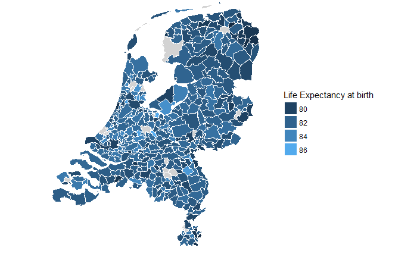

```r
AddMapLayer(MapPlot(), map_municipal, map_info) +
  guides(fill = guide_legend(title = "Life Expectancy at birth"))
```

```r
map_info4 <- d1 %>%
mutate( Hulp= ifelse(LEtotalpop>85,1,0))
str(map_info4)
```

```
'data.frame':   374 obs. of  30 variables:
 $ X                                   : int  1 2 3 4 5 6 7 8 9 10 ...
 $ LEtotalpop                          : num  82.5 80.9 83.2 82 81 82.8 82.7 81.7 79.7 81.8 ...
 $ LEwomen                             : num  85 81.9 85.7 84.1 83.1 84.6 84.4 83.6 81.6 83.3 ...
 $ LEmen                               : num  80 79.8 80.8 79.9 78.9 81.1 80.9 79.7 77.7 80.3 ...
 $ Gemeente                            : Factor w/ 374 levels "'s-Hertogenbosch",..: 2 3 4 5 6 7 8 9 10 11 ...
 $ Gescheiden_32                       : num  8.2 5.3 7.7 6.1 7.5 7.2 8.8 11 9.8 11.2 ...
 $ TotaalMetMigratieachtergrond_44     : num  5.9 5.5 18.1 11 4 13.6 19.3 21.6 24.9 40 ...
 $ Bevolkingsdichtheid_57              : int  91 259 1555 279 274 2270 1150 974 1076 1533 ...
 $ GemiddeldeHuishoudensgrootte_89     : num  2.26 2.65 2.41 2.35 2.39 2.46 2.43 2.1 2.24 2.38 ...
 $ Woningdichtheid_93                  : int  40 100 640 122 117 935 470 456 482 617 ...
 $ Koopwoningen_94                     : num  71.1 71.7 63.1 69.4 63.3 60.1 67.3 57.7 54.6 63.8 ...
 $ GemiddeldeWoningwaarde_99           : int  218 239 269 185 159 194 248 183 151 181 ...
 $ AfstandTotZiekenhuis_216            : num  11.5 11.8 9.7 14.5 15.7 8.5 6.3 4 3.7 4.4 ...
 $ TotaleBevolking_1                   : int  25243 13038 31299 26912 28007 19955 24985 107615 72425 198145 ...
```

[output cut: 16 more lines]

```r
map_info5 <- map_info4 %>%
  select(Gemeente, Hulp)
```

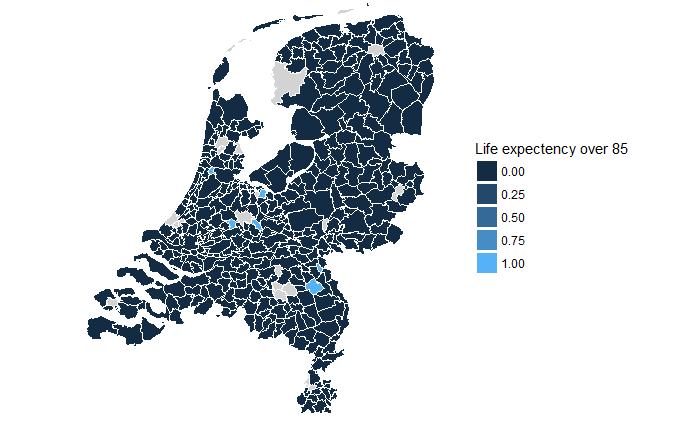

```r
 AddMapLayer(MapPlot(), map_municipal, map_info5) +
  guides(fill = guide_legend(title = "Life expectency over 85"))
```

```r
map_info6 <- d1 %>%
mutate( Hulp2= ifelse(LEtotalpop<80,1,0))
str(map_info4)
```

```
'data.frame':   374 obs. of  30 variables:
 $ X                                   : int  1 2 3 4 5 6 7 8 9 10 ...
 $ LEtotalpop                          : num  82.5 80.9 83.2 82 81 82.8 82.7 81.7 79.7 81.8 ...
 $ LEwomen                             : num  85 81.9 85.7 84.1 83.1 84.6 84.4 83.6 81.6 83.3 ...
 $ LEmen                               : num  80 79.8 80.8 79.9 78.9 81.1 80.9 79.7 77.7 80.3 ...
 $ Gemeente                            : Factor w/ 374 levels "'s-Hertogenbosch",..: 2 3 4 5 6 7 8 9 10 11 ...
 $ Gescheiden_32                       : num  8.2 5.3 7.7 6.1 7.5 7.2 8.8 11 9.8 11.2 ...
 $ TotaalMetMigratieachtergrond_44     : num  5.9 5.5 18.1 11 4 13.6 19.3 21.6 24.9 40 ...
 $ Bevolkingsdichtheid_57              : int  91 259 1555 279 274 2270 1150 974 1076 1533 ...
 $ GemiddeldeHuishoudensgrootte_89     : num  2.26 2.65 2.41 2.35 2.39 2.46 2.43 2.1 2.24 2.38 ...
 $ Woningdichtheid_93                  : int  40 100 640 122 117 935 470 456 482 617 ...
 $ Koopwoningen_94                     : num  71.1 71.7 63.1 69.4 63.3 60.1 67.3 57.7 54.6 63.8 ...
 $ GemiddeldeWoningwaarde_99           : int  218 239 269 185 159 194 248 183 151 181 ...
 $ AfstandTotZiekenhuis_216            : num  11.5 11.8 9.7 14.5 15.7 8.5 6.3 4 3.7 4.4 ...
 $ TotaleBevolking_1                   : int  25243 13038 31299 26912 28007 19955 24985 107615 72425 198145 ...
```

[output cut: 16 more lines]

```r
map_info7 <- map_info6 %>%
  select(Gemeente, Hulp2)
```

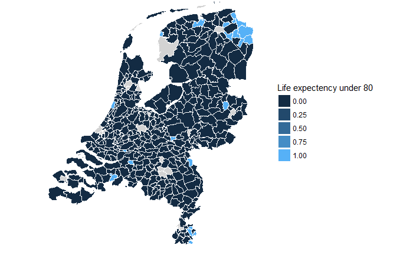

```r
AddMapLayer(MapPlot(), map_municipal, map_info7) +
  guides(fill = guide_legend(title = "Life expectency under 80"))
```

```r
map_info13 <- d1 %>%
  select(Gemeente, LEmen)
```

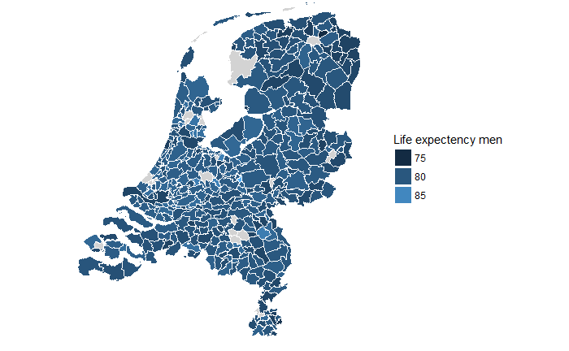

```r
AddMapLayer(MapPlot(), map_municipal, map_info13) +
  guides(fill = guide_legend(title = "Life expectency men"))
```

```r
map_info14 <- d1 %>%
  select(Gemeente, LEwomen)
```

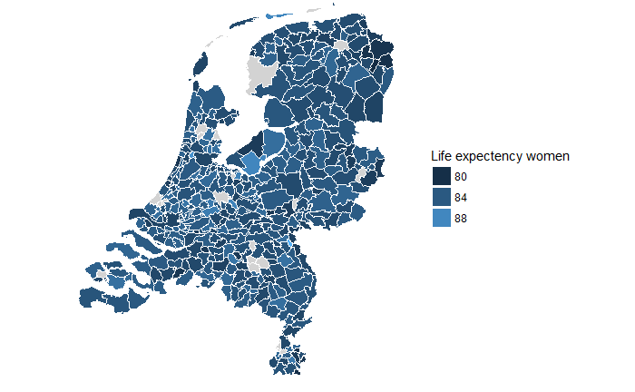

```r
AddMapLayer(MapPlot(), map_municipal, map_info14) +
  guides(fill = guide_legend(title = "Life expectency women"))
```

```r
hulpmapinfo15 <- d1 %>%
  mutate(Verschil.in.LE = (LEwomen - LEmen))
```

```r
mapinfo15 <- hulpmapinfo15 %>%
  select(Gemeente,  Verschil.in.LE)
```

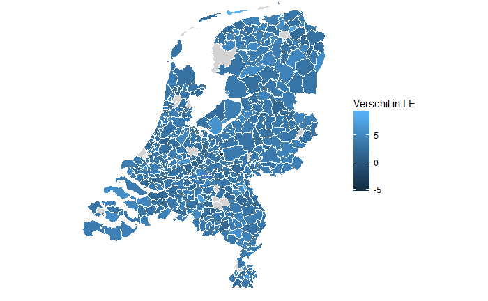

```r
AddMapLayer(MapPlot(), map_municipal, mapinfo15)
```

```r
map_info2 <- d1 %>%
    select(Gemeente, Totaal.bekende.CO2.uitstoot.2016)
```

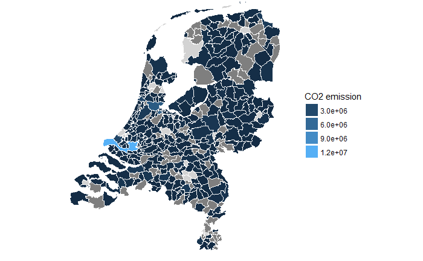

```r
AddMapLayer(MapPlot(), map_municipal, map_info2) +
  guides(fill = guide_legend(title = "CO2 emission"))
```

```r
d1a1 <- d1 %>%
mutate(uitstoot.per.capita = (Totaal.bekende.CO2.uitstoot.2016/TotaleBevolking_1))
```

```r
map_info2a <- d1a1 %>%
    select(Gemeente, uitstoot.per.capita)
```

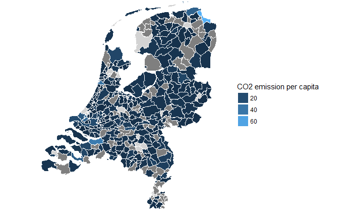

```r
AddMapLayer(MapPlot(), map_municipal, map_info2a) +
  guides(fill = guide_legend(title = "CO2 emission per capita"))
```

```r
map_info3 <- d1 %>%
    select(Gemeente, WekelijkseSporters_16)
```

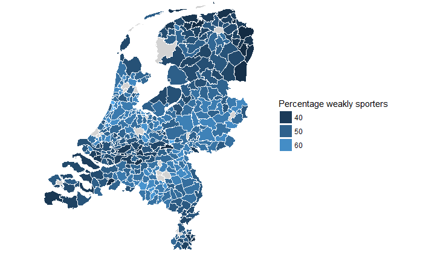

```r
AddMapLayer(MapPlot(), map_municipal, map_info3) +
  guides(fill = guide_legend(title = "Percentage weakly sporters"))
```

```r
map_info8 <- d1 %>%
    select(Gemeente, GemiddeldeWoningwaarde_99)
```

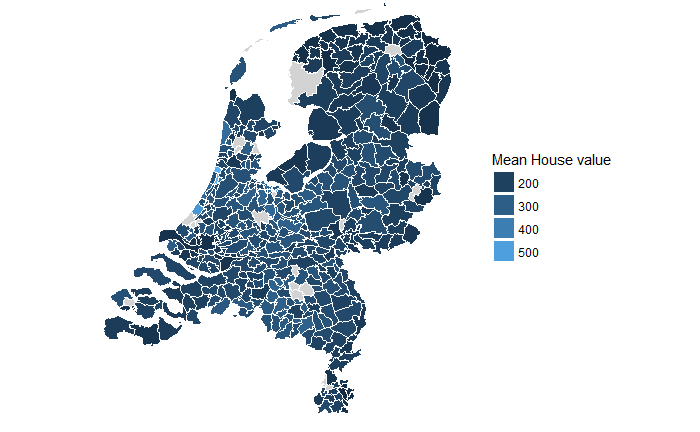

```r
AddMapLayer(MapPlot(), map_municipal, map_info8) +
  guides(fill = guide_legend(title = "Mean House value"))
```

```r
map_info9 <- d1 %>%
    select(Gemeente, AfstandTotZiekenhuis_216)
```

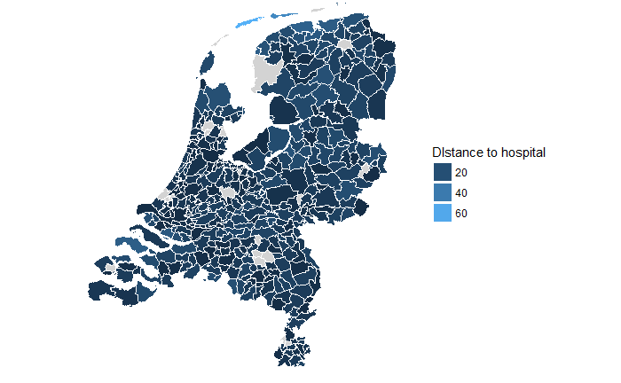

```r
AddMapLayer(MapPlot(), map_municipal, map_info9) +
  guides(fill = guide_legend(title = "DIstance to hospital"))
```

```r
map_info10 <- d1 %>%
    select(Gemeente, TotaleBevolking_1)
```

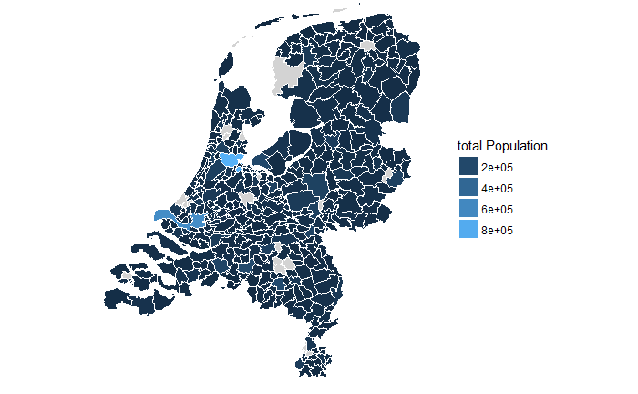

```r
AddMapLayer(MapPlot(), map_municipal, map_info10) +
  guides(fill = guide_legend(title = "total Population"))
```

```r
map_info11 <- d1 %>%
    select(Gemeente, TotaalMetMigratieachtergrond_44)
```

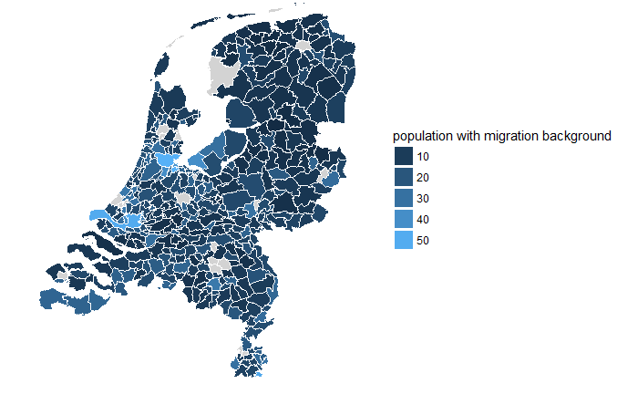

```r
AddMapLayer(MapPlot(), map_municipal, map_info11) +
  guides(fill = guide_legend(title = "population with migration background"))
```

```r
map_info12 <- d1 %>%
    select(Gemeente, Koopwoningen_94)
```

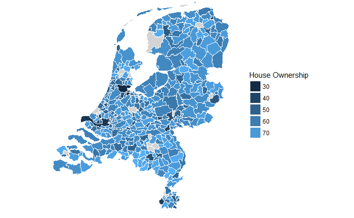

```r
AddMapLayer(MapPlot(), map_municipal, map_info12) +
  guides(fill = guide_legend(title = "House Ownership"))
```

# Graphs

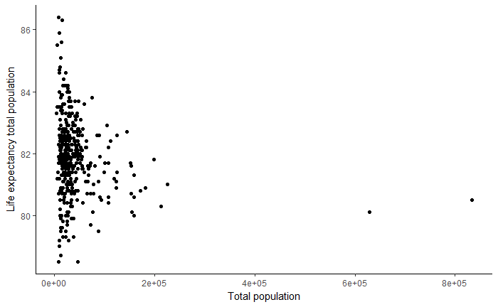

```r
 ggplot(d1, aes(x=TotaleBevolking_1, y=LEtotalpop)) + geom_point()+ theme_classic() + xlab("Total population") + ylab("Life expectancy total population")
```

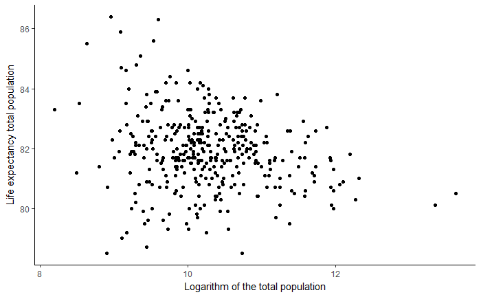

```r
 ggplot(d1, aes(x=log(TotaleBevolking_1), y=LEtotalpop)) + geom_point() + theme_classic()+ xlab("Logarithm of the total population") + ylab("Life expectancy total population")
```

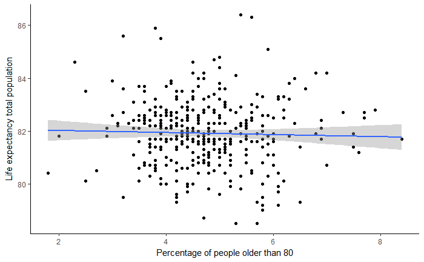

```r
ggplot(d1, aes(x=k_80JaarOfOuder_21, y=LEtotalpop)) + geom_point()+geom_smooth(method = "lm") + theme_classic()+ xlab("Percentage of people older than 80") + ylab("Life expectancy total population")
```

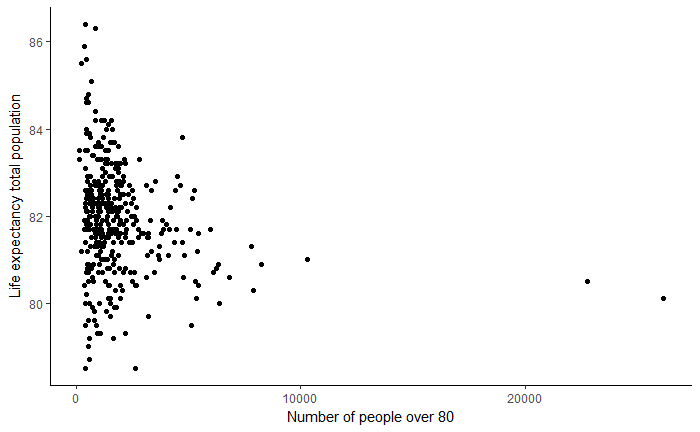

```r
ggplot(d1, aes(x=k_80JaarOfOuder_12, y=LEtotalpop)) + geom_point() + theme_classic()+ xlab("Number of people over 80") + ylab("Life expectancy total population")
```

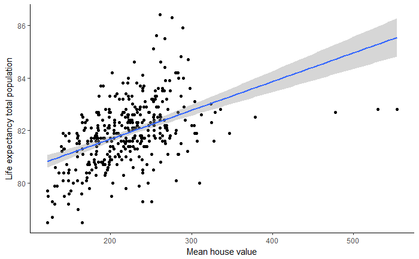

```r
ggplot(d1, aes(x=GemiddeldeWoningwaarde_99, y=LEtotalpop)) + geom_point() + geom_smooth(method = "lm") + theme_classic()+ xlab("Mean house value") + ylab("Life expectancy total population")
```

```r
d_MHV <- d1 %>%
  select(Gemeente, GemiddeldeWoningwaarde_99, LEmen, LEwomen) %>%
  gather(Soort, LE, 3:4)
```

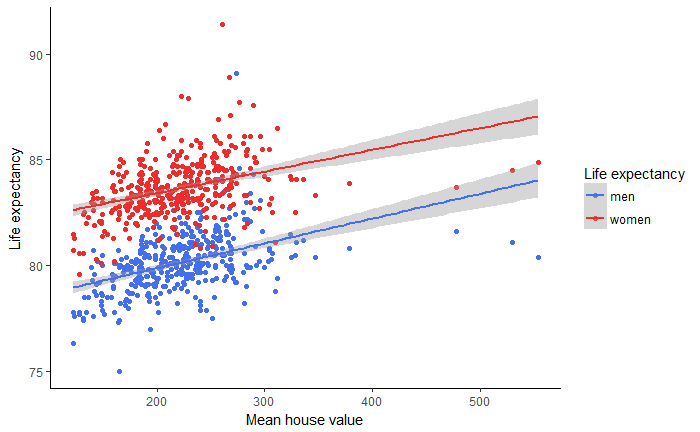

```r
ggplot(d_MHV, aes(x=GemiddeldeWoningwaarde_99, y=LE, group=Soort, color= Soort)) + geom_point() + geom_smooth(method= "lm") + theme_classic() + xlab("Mean house value") + ylab("Life expectancy") + scale_colour_manual(
                       values=c("royalblue2", "firebrick2"),
                       name="Life expectancy",
                       breaks=c("LEmen", "LEwomen"),
                       labels=c("men", "women"))
```

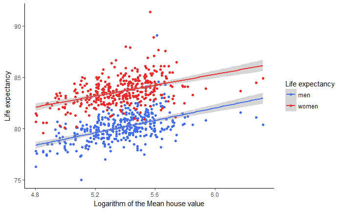

```r
ggplot(d_MHV, aes(x=log(GemiddeldeWoningwaarde_99), y=LE, group=Soort, color= Soort)) + geom_point() + geom_smooth(method= "lm") + theme_classic()+ xlab("Logarithm of the Mean house value") + ylab("Life expectancy") + scale_colour_manual(
                       values=c("royalblue2", "firebrick2"),
                       name="Life expectancy",
                       breaks=c("LEmen", "LEwomen"),
                       labels=c("men", "women"))
```

```r
d_LOP <- d1 %>%
  select(Gemeente, LagerOpgeleidenPercentage_5, LEmen, LEwomen) %>%
  gather(Soort, LE, 3:4)
```

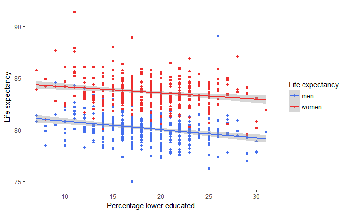

```r
ggplot(d_LOP, aes(x=LagerOpgeleidenPercentage_5, y=LE, group=Soort, color= Soort)) + geom_point() + geom_smooth(method= "lm") + theme_classic()+ xlab("Percentage lower educated") + ylab("Life expectancy") + scale_colour_manual(
                       values=c("royalblue2", "firebrick2"),
                       name="Life expectancy",
                       breaks=c("LEmen", "LEwomen"),
                       labels=c("men", "women"))
```

```r
d_ISM <- d1 %>%
  select(Gemeente, InkomenTot120SociaalMinimum_13, LEmen, LEwomen) %>%
  gather(Soort, LE, 3:4)
```

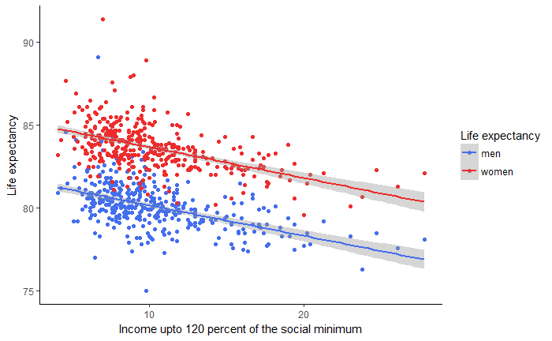

```r
ggplot(d_ISM, aes(x=InkomenTot120SociaalMinimum_13, y=LE, group=Soort, color= Soort)) + geom_point() + geom_smooth(method= "lm") + theme_classic()+ xlab("Income upto 120 percent of the social minimum") + ylab("Life expectancy") + scale_colour_manual(
                       values=c("royalblue2", "firebrick2"),
                       name="Life expectancy",
                       breaks=c("LEmen", "LEwomen"),
                       labels=c("men", "women"))
```

```r
d_GGI <- d1 %>%
  select(Gemeente, GemiddeldGestandaardiseerdInkomen_41, LEmen, LEwomen) %>%
  gather(Soort, LE, 3:4)
```

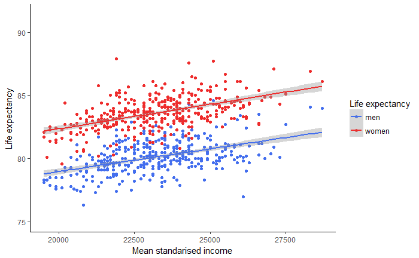

```r
ggplot(d_GGI, aes(x=GemiddeldGestandaardiseerdInkomen_41, y=LE, group=Soort, color= Soort)) + geom_point() + geom_smooth(method= "lm") + theme_classic()+ xlab("Mean standarised income") + ylab("Life expectancy") + scale_colour_manual(
                       values=c("royalblue2", "firebrick2"),
                       name="Life expectancy",
                       breaks=c("LEmen", "LEwomen"),
                       labels=c("men", "women"))
```

```r
d_EGGZG <- d1 %>%
  select(Gemeente, ErvarenGezondheidGoedZeerGoed_1, LEmen, LEwomen) %>%
  gather(Soort, LE, 3:4)
```

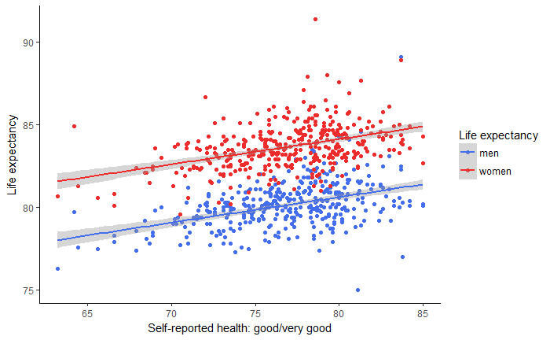

```r
ggplot(d_EGGZG, aes(x=ErvarenGezondheidGoedZeerGoed_1, y=LE, group=Soort, color= Soort)) + geom_point() + geom_smooth(method= "lm") + theme_classic() + xlab("Self-reported health: good/very good") + ylab("Life expectancy") + scale_colour_manual(
                       values=c("royalblue2", "firebrick2"),
                       name="Life expectancy",
                       breaks=c("LEmen", "LEwomen"),
                       labels=c("men", "women"))
```

```r
d_TMMA <- d1 %>%
  select(Gemeente, TotaalMetMigratieachtergrond_44, LEmen, LEwomen) %>%
  gather(Soort, LE, 3:4)
```

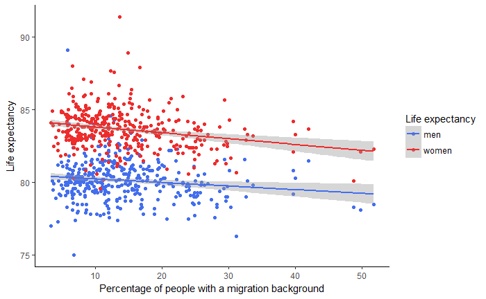

```r
ggplot(d_TMMA, aes(x=TotaalMetMigratieachtergrond_44, y=LE, group=Soort, color= Soort)) + geom_point() + geom_smooth(method= "lm") + theme_classic() + xlab("Percentage of people with a migration background") + ylab("Life expectancy") + scale_colour_manual(
                       values=c("royalblue2", "firebrick2"),
                       name="Life expectancy",
                       breaks=c("LEmen", "LEwomen"),
                       labels=c("men", "women"))
```

```r
d_ATZ <- d1 %>%
  select(Gemeente, AfstandTotZiekenhuis_216, LEmen, LEwomen) %>%
  gather(Soort, LE, 3:4)
```

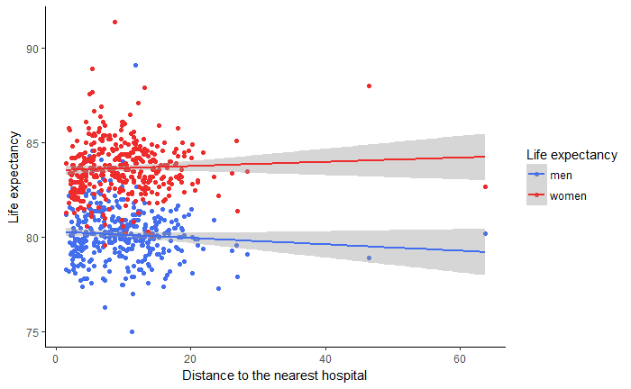

```r
ggplot(d_ATZ, aes(x=AfstandTotZiekenhuis_216, y=LE, group=Soort, color= Soort)) + geom_point() + geom_smooth(method= "lm") + theme_classic() + xlab("Distance to the nearest hospital") + ylab("Life expectancy") + scale_colour_manual(
                       values=c("royalblue2", "firebrick2"),
                       name="Life expectancy",
                       breaks=c("LEmen", "LEwomen"),
                       labels=c("men", "women"))
```

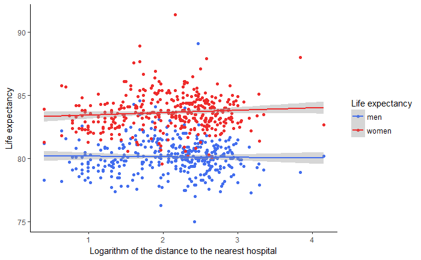

```r
ggplot(d_ATZ, aes(x=log(AfstandTotZiekenhuis_216), y=LE, group=Soort, color= Soort)) + geom_point() + geom_smooth(method= "lm") +theme_classic()+ xlab("Logarithm of the distance to the nearest hospital") + ylab("Life expectancy") + scale_colour_manual(
                       values=c("royalblue2", "firebrick2"),
                       name="Life expectancy",
                       breaks=c("LEmen", "LEwomen"),
                       labels=c("men", "women"))
```

# Collinearity

```r
d1a <- d1a1 %>%
  select(-X, -Gemeente, -RegioS)
str(d1a)
```

```
'data.frame':   374 obs. of  27 variables:
 $ LEtotalpop                          : num  82.5 80.9 83.2 82 81 82.8 82.7 81.7 79.7 81.8 ...
 $ LEwomen                             : num  85 81.9 85.7 84.1 83.1 84.6 84.4 83.6 81.6 83.3 ...
 $ LEmen                               : num  80 79.8 80.8 79.9 78.9 81.1 80.9 79.7 77.7 80.3 ...
 $ Gescheiden_32                       : num  8.2 5.3 7.7 6.1 7.5 7.2 8.8 11 9.8 11.2 ...
 $ TotaalMetMigratieachtergrond_44     : num  5.9 5.5 18.1 11 4 13.6 19.3 21.6 24.9 40 ...
 $ Bevolkingsdichtheid_57              : int  91 259 1555 279 274 2270 1150 974 1076 1533 ...
 $ GemiddeldeHuishoudensgrootte_89     : num  2.26 2.65 2.41 2.35 2.39 2.46 2.43 2.1 2.24 2.38 ...
 $ Woningdichtheid_93                  : int  40 100 640 122 117 935 470 456 482 617 ...
 $ Koopwoningen_94                     : num  71.1 71.7 63.1 69.4 63.3 60.1 67.3 57.7 54.6 63.8 ...
 $ GemiddeldeWoningwaarde_99           : int  218 239 269 185 159 194 248 183 151 181 ...
 $ AfstandTotZiekenhuis_216            : num  11.5 11.8 9.7 14.5 15.7 8.5 6.3 4 3.7 4.4 ...
 $ TotaleBevolking_1                   : int  25243 13038 31299 26912 28007 19955 24985 107615 72425 198145 ...
 $ k_80JaarOfOuder_21                  : num  5.6 3.8 4.5 5.2 4 4.9 3.8 4.1 4.4 2 ...
 $ k_80JaarOfOuder_12                  : int  1408 490 1398 1397 1125 985 944 4457 3192 4009 ...
 $ GemiddeldGestandaardiseerdInkomen_41: int  23000 23700 25000 23500 20900 22500 24800 21500 20100 21000 ...
 $ InkomenTot120SociaalMinimum_13      : num  8.2 6.2 6.6 7.6 13 8.7 6.7 11.9 17.6 16 ...
 $ LagerOpgeleidenPercentage_5         : int  12 31 23 20 30 18 14 16 21 17 ...
 $ Percentage_eenpersoonshuishoudens   : num  26.4 23.3 27.9 27.9 28.7 ...
 $ gemeente                            : Factor w/ 374 levels "'s-Hertogenbosch",..: 2 3 4 5 6 7 8 9 10 11 ...
 $ ErvarenGezondheidGoedZeerGoed_1     : num  79.5 78.7 80.5 75.6 81.3 75.3 77.9 72.6 72.3 73.2 ...
 $ EenOfMeerLangdurigeAandoeningen_2   : num  33.5 24.9 31.3 35 35.9 33.4 32.1 36.2 38.2 34.1 ...
 $ NormaalGewicht_9                    : num  43.7 47.4 49 45.8 40.8 47.9 47.8 52.7 42.9 44 ...
 $ VoldoetAanFitnorm_14                : num  28.6 21.2 26.9 31.7 26.1 19.9 22.3 28.2 32 18.7 ...
 $ UrenMantelzorgPerWeek_19            : num  12.8 9.7 8 8.4 NA NA NA 8.7 10.2 16.4 ...
 $ WekelijkseSporters_16               : num  46.3 38.3 54.3 47.9 41.7 42.3 50.1 53.3 47.1 49.7 ...
 $ Totaal.bekende.CO2.uitstoot.2016    : int  NA NA NA 134297 159597 201343 117913 579053 571012 831527 ...
 $ uitstoot.per.capita                 : num  NA NA NA 4.99 5.7 ...
```

```r
d1b <- d1a %>%
  select(LE = LEtotalpop, Divorced= Gescheiden_32, Migration = TotaalMetMigratieachtergrond_44, House_O = Koopwoningen_94, Mean_inc = GemiddeldGestandaardiseerdInkomen_41, Lower_edu = LagerOpgeleidenPercentage_5, Pop_density = Bevolkingsdichtheid_57, House_density = Woningdichtheid_93, Mean_HV = GemiddeldeWoningwaarde_99, Dist_Hosp = AfstandTotZiekenhuis_216, Inc_SM = InkomenTot120SociaalMinimum_13, onepers_HH = Percentage_eenpersoonshuishoudens, Health_status_very_good = ErvarenGezondheidGoedZeerGoed_1, Multi_morbidity = EenOfMeerLangdurigeAandoeningen_2, Normal_weight= NormaalGewicht_9, Fit_norm=VoldoetAanFitnorm_14, Informal_care=UrenMantelzorgPerWeek_19, Weekly_sporters = WekelijkseSporters_16, EmissionCO2=uitstoot.per.capita)
```

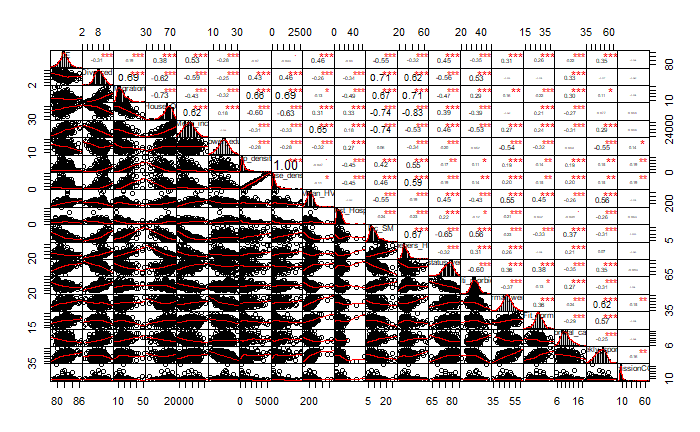

```r
suppressWarnings(chart.Correlation(d1b))
```

```
Correlation method: 'pearson'
Missing treated using: 'pairwise.complete.obs'
```

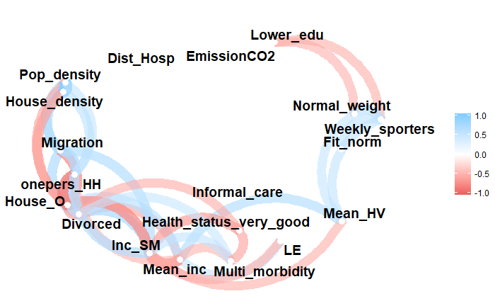

```r
d1b %>%
  correlate() %>%
  network_plot(min_cor = .5, repel= TRUE, curved = TRUE, legend = TRUE)
```

# Analysis

```r
d2 <- d1a1 %>%
  select(-Gemeente,-gemeente, -X , -RegioS, -LEmen, -LEwomen, -uitstoot.per.capita, -Totaal.bekende.CO2.uitstoot.2016)
```

```r
lm1 <- lm(LEtotalpop ~  ., data = d2)
summary(lm1)
```

```
Call:
lm(formula = LEtotalpop ~ ., data = d2)

Residuals:
     Min       1Q   Median       3Q      Max
-2.24009 -0.53852 -0.01378  0.56261  2.80073

Coefficients:
                                       Estimate Std. Error t value Pr(>|t|)
(Intercept)                           6.873e+01  4.783e+00  14.371  < 2e-16 ***
Gescheiden_32                         7.494e-02  7.124e-02   1.052 0.293751
TotaalMetMigratieachtergrond_44       2.881e-02  1.532e-02   1.881 0.061014 .
Bevolkingsdichtheid_57                2.655e-04  9.794e-04   0.271 0.786486
GemiddeldeHuishoudensgrootte_89       6.893e-01  1.152e+00   0.598 0.550113
Woningdichtheid_93                   -4.282e-04  2.182e-03  -0.196 0.844536
Koopwoningen_94                       2.576e-02  1.488e-02   1.731 0.084450 .
GemiddeldeWoningwaarde_99            -1.084e-03  1.704e-03  -0.636 0.525031
AfstandTotZiekenhuis_216             -2.817e-02  1.452e-02  -1.940 0.053402 .
TotaleBevolking_1                    -1.992e-07  3.529e-06  -0.056 0.955025
k_80JaarOfOuder_21                    1.236e-02  8.791e-02   0.141 0.888286
k_80JaarOfOuder_12                    3.735e-06  9.911e-05   0.038 0.969964
GemiddeldGestandaardiseerdInkomen_41  2.130e-04  5.702e-05   3.736 0.000225 ***
InkomenTot120SociaalMinimum_13       -8.556e-02  3.551e-02  -2.409 0.016602 *
LagerOpgeleidenPercentage_5          -4.272e-02  1.779e-02  -2.401 0.016973 *
Percentage_eenpersoonshuishoudens    -2.761e-03  3.248e-02  -0.085 0.932309
ErvarenGezondheidGoedZeerGoed_1       8.329e-02  2.487e-02   3.348 0.000920 ***
EenOfMeerLangdurigeAandoeningen_2     2.495e-02  2.040e-02   1.223 0.222399
NormaalGewicht_9                     -1.283e-02  1.942e-02  -0.661 0.509303
VoldoetAanFitnorm_14                  4.079e-04  1.929e-02   0.021 0.983143
UrenMantelzorgPerWeek_19             -9.331e-03  2.172e-02  -0.430 0.667793
WekelijkseSporters_16                -7.608e-03  1.519e-02  -0.501 0.616955
---
Signif. codes:  0 *** 0.001 ** 0.01 * 0.05 . 0.1   1

Residual standard error: 0.8818 on 291 degrees of freedom
  (61 observations deleted due to missingness)
Multiple R-squared:  0.4467,    Adjusted R-squared:  0.4068
F-statistic: 11.19 on 21 and 291 DF,  p-value: < 2.2e-16
```

## Multicollinearity

### VIF

```r
vif(lm1)
```

```
                       Gescheiden_32      TotaalMetMigratieachtergrond_44               Bevolkingsdichtheid_57
                            5.705206                             5.810465                           365.393594
     GemiddeldeHuishoudensgrootte_89                   Woningdichtheid_93                      Koopwoningen_94
                           14.503591                           390.954875                             5.874586
           GemiddeldeWoningwaarde_99             AfstandTotZiekenhuis_216                    TotaleBevolking_1
                            3.153901                             1.913766                            21.865585
                  k_80JaarOfOuder_21                   k_80JaarOfOuder_12 GemiddeldGestandaardiseerdInkomen_41
                            3.010674                            21.555904                             3.719655
      InkomenTot120SociaalMinimum_13          LagerOpgeleidenPercentage_5    Percentage_eenpersoonshuishoudens
                            7.151678                             2.521600                            16.793665
     ErvarenGezondheidGoedZeerGoed_1    EenOfMeerLangdurigeAandoeningen_2                     NormaalGewicht_9
                            3.371330                             2.153334                             2.895083
                VoldoetAanFitnorm_14             UrenMantelzorgPerWeek_19                WekelijkseSporters_16
                            2.580801                             1.275771                             3.172771
```

We exclude the variable with the highest VIF (Which Woningdichtheid_93) and then run a VIF again.

```r
lm1a <- lm(LEtotalpop ~  . -Woningdichtheid_93, data = d2)
vif(lm1a)
```

```
                       Gescheiden_32      TotaalMetMigratieachtergrond_44               Bevolkingsdichtheid_57
                            5.605589                             5.807076                             2.386683
     GemiddeldeHuishoudensgrootte_89                      Koopwoningen_94            GemiddeldeWoningwaarde_99
                           14.264664                             5.868994                             3.153779
            AfstandTotZiekenhuis_216                    TotaleBevolking_1                   k_80JaarOfOuder_21
                            1.904859                            20.593716                             2.866814
                  k_80JaarOfOuder_12 GemiddeldGestandaardiseerdInkomen_41       InkomenTot120SociaalMinimum_13
                           20.842889                             3.664997                             6.688891
         LagerOpgeleidenPercentage_5    Percentage_eenpersoonshuishoudens      ErvarenGezondheidGoedZeerGoed_1
                            2.512324                            16.394575                             3.369972
   EenOfMeerLangdurigeAandoeningen_2                     NormaalGewicht_9                 VoldoetAanFitnorm_14
                            2.152358                             2.894579                             2.510979
            UrenMantelzorgPerWeek_19                WekelijkseSporters_16
                            1.263101                             3.161343
```

```r
lm1b <- lm(LEtotalpop ~  . -Woningdichtheid_93 -k_80JaarOfOuder_12 , data = d2)
vif(lm1b)
```

```
                       Gescheiden_32      TotaalMetMigratieachtergrond_44               Bevolkingsdichtheid_57
                            5.518427                             5.798244                             2.373824
     GemiddeldeHuishoudensgrootte_89                      Koopwoningen_94            GemiddeldeWoningwaarde_99
                           13.820104                             5.860578                             3.056180
            AfstandTotZiekenhuis_216                    TotaleBevolking_1                   k_80JaarOfOuder_21
                            1.884955                             2.145838                             2.159121
GemiddeldGestandaardiseerdInkomen_41       InkomenTot120SociaalMinimum_13          LagerOpgeleidenPercentage_5
                            3.664788                             6.688802                             2.494810
   Percentage_eenpersoonshuishoudens      ErvarenGezondheidGoedZeerGoed_1    EenOfMeerLangdurigeAandoeningen_2
                           15.903170                             3.361021                             2.139249
                    NormaalGewicht_9                 VoldoetAanFitnorm_14             UrenMantelzorgPerWeek_19
                            2.894554                             2.508490                             1.262561
               WekelijkseSporters_16
                            3.129932
```

Now we have to exclude Percentage_eenpersoonshuishoudens

```r
lm1c <- lm(LEtotalpop ~  . -Woningdichtheid_93 -k_80JaarOfOuder_12 -Percentage_eenpersoonshuishoudens , data = d2)
vif(lm1c)
```

```
                       Gescheiden_32      TotaalMetMigratieachtergrond_44               Bevolkingsdichtheid_57
                            4.625759                             5.428687                             2.344712
     GemiddeldeHuishoudensgrootte_89                      Koopwoningen_94            GemiddeldeWoningwaarde_99
                            5.456101                             4.307679                             3.045132
            AfstandTotZiekenhuis_216                    TotaleBevolking_1                   k_80JaarOfOuder_21
                            1.882441                             2.137890                             2.048042
GemiddeldGestandaardiseerdInkomen_41       InkomenTot120SociaalMinimum_13          LagerOpgeleidenPercentage_5
                            3.630407                             6.615487                             2.487965
     ErvarenGezondheidGoedZeerGoed_1    EenOfMeerLangdurigeAandoeningen_2                     NormaalGewicht_9
                            3.232984                             2.122261                             2.269688
                VoldoetAanFitnorm_14             UrenMantelzorgPerWeek_19                WekelijkseSporters_16
                            2.508352                             1.262439                             3.077148
```

We have to exclude InkomenTot120SociaalMinimum_13

```r
lm1d <- lm(LEtotalpop ~  . -Woningdichtheid_93 -k_80JaarOfOuder_12 -Percentage_eenpersoonshuishoudens -InkomenTot120SociaalMinimum_13 , data = d2)
vif(lm1d)
```

```
                       Gescheiden_32      TotaalMetMigratieachtergrond_44               Bevolkingsdichtheid_57
                            4.440087                             5.236904                             2.341934
     GemiddeldeHuishoudensgrootte_89                      Koopwoningen_94            GemiddeldeWoningwaarde_99
                            5.252130                             4.112214                             3.003954
            AfstandTotZiekenhuis_216                    TotaleBevolking_1                   k_80JaarOfOuder_21
                            1.880795                             1.965704                             2.047186
GemiddeldGestandaardiseerdInkomen_41          LagerOpgeleidenPercentage_5      ErvarenGezondheidGoedZeerGoed_1
                            3.513078                             2.356467                             3.133783
   EenOfMeerLangdurigeAandoeningen_2                     NormaalGewicht_9                 VoldoetAanFitnorm_14
                            2.108718                             2.269499                             2.507794
            UrenMantelzorgPerWeek_19                WekelijkseSporters_16
                            1.262068                             3.053537
```

We have to exclude GemiddeldeHuishoudensgrootte_89

```r
lm1e <- lm(LEtotalpop ~  . -Woningdichtheid_93 -k_80JaarOfOuder_12 -Percentage_eenpersoonshuishoudens -InkomenTot120SociaalMinimum_13 -GemiddeldeHuishoudensgrootte_89, data = d2)
vif(lm1e)
```

```
                       Gescheiden_32      TotaalMetMigratieachtergrond_44               Bevolkingsdichtheid_57
                            4.052095                             5.219084                             2.341277
                     Koopwoningen_94            GemiddeldeWoningwaarde_99             AfstandTotZiekenhuis_216
                            3.448235                             2.870664                             1.850349
                   TotaleBevolking_1                   k_80JaarOfOuder_21 GemiddeldGestandaardiseerdInkomen_41
                            1.956895                             1.651725                             3.504535
         LagerOpgeleidenPercentage_5      ErvarenGezondheidGoedZeerGoed_1    EenOfMeerLangdurigeAandoeningen_2
                            2.282380                             2.864838                             2.105555
                    NormaalGewicht_9                 VoldoetAanFitnorm_14             UrenMantelzorgPerWeek_19
                            2.195265                             2.507577                             1.261347
               WekelijkseSporters_16
                            2.980982
```

We have to exclude TotaalMetMigratieachtergrond_44

```r
lm1f <- lm(LEtotalpop ~  . -Woningdichtheid_93 -k_80JaarOfOuder_12 -Percentage_eenpersoonshuishoudens -InkomenTot120SociaalMinimum_13 -GemiddeldeHuishoudensgrootte_89 -TotaalMetMigratieachtergrond_44, data = d2)
vif(lm1f)
```

```
                       Gescheiden_32               Bevolkingsdichtheid_57                      Koopwoningen_94
                            3.457348                             2.138669                             3.053491
           GemiddeldeWoningwaarde_99             AfstandTotZiekenhuis_216                    TotaleBevolking_1
                            2.869530                             1.804012                             1.757886
                  k_80JaarOfOuder_21 GemiddeldGestandaardiseerdInkomen_41          LagerOpgeleidenPercentage_5
                            1.644660                             3.404595                             2.260617
     ErvarenGezondheidGoedZeerGoed_1    EenOfMeerLangdurigeAandoeningen_2                     NormaalGewicht_9
                            2.713071                             2.091726                             2.193777
                VoldoetAanFitnorm_14             UrenMantelzorgPerWeek_19                WekelijkseSporters_16
                            2.481170                             1.254677                             2.961695
```

```r
lm2 <- lm(LEtotalpop ~  . -Woningdichtheid_93 -k_80JaarOfOuder_12 -Percentage_eenpersoonshuishoudens -InkomenTot120SociaalMinimum_13 -GemiddeldeHuishoudensgrootte_89 -TotaalMetMigratieachtergrond_44, data = d2)
summary(lm2)
```

```
Call:
lm(formula = LEtotalpop ~ . - Woningdichtheid_93 - k_80JaarOfOuder_12 -
    Percentage_eenpersoonshuishoudens - InkomenTot120SociaalMinimum_13 -
    GemiddeldeHuishoudensgrootte_89 - TotaalMetMigratieachtergrond_44,
    data = d2)

Residuals:
    Min      1Q  Median      3Q     Max
-2.1724 -0.5719 -0.0007  0.5186  2.8505

Coefficients:
                                       Estimate Std. Error t value Pr(>|t|)
(Intercept)                           6.780e+01  3.132e+00  21.651  < 2e-16 ***
Gescheiden_32                         4.733e-02  5.596e-02   0.846 0.398416
Bevolkingsdichtheid_57                1.133e-04  7.561e-05   1.498 0.135136
Koopwoningen_94                       3.662e-02  1.082e-02   3.383 0.000813 ***
GemiddeldeWoningwaarde_99             1.905e-05  1.640e-03   0.012 0.990739
AfstandTotZiekenhuis_216             -3.582e-02  1.423e-02  -2.518 0.012344 *
TotaleBevolking_1                    -5.813e-07  1.010e-06  -0.576 0.565169
k_80JaarOfOuder_21                   -4.253e-02  6.556e-02  -0.649 0.517062
GemiddeldGestandaardiseerdInkomen_41  2.556e-04  5.505e-05   4.644 5.15e-06 ***
LagerOpgeleidenPercentage_5          -5.043e-02  1.700e-02  -2.967 0.003250 **
ErvarenGezondheidGoedZeerGoed_1       9.825e-02  2.252e-02   4.364 1.77e-05 ***
EenOfMeerLangdurigeAandoeningen_2     1.987e-02  2.029e-02   0.979 0.328195
NormaalGewicht_9                     -1.810e-02  1.706e-02  -1.061 0.289496
VoldoetAanFitnorm_14                 -1.238e-03  1.908e-02  -0.065 0.948317
UrenMantelzorgPerWeek_19             -8.597e-03  2.173e-02  -0.396 0.692719
WekelijkseSporters_16                -6.381e-03  1.481e-02  -0.431 0.666936
---
Signif. codes:  0 *** 0.001 ** 0.01 * 0.05 . 0.1   1

Residual standard error: 0.8897 on 297 degrees of freedom
  (61 observations deleted due to missingness)
Multiple R-squared:  0.425, Adjusted R-squared:  0.396
F-statistic: 14.64 on 15 and 297 DF,  p-value: < 2.2e-16
```

## Overfitting

We need complete cases

```r
d2a <- d2 %>%
  na.omit()
```

Split dataset in train and test set

```r
set.seed(123)
trainIndex <- createDataPartition(d2a$LEtotalpop, p=.8,
                                  list=FALSE,
                                  times =1)
df_train <- d2a[trainIndex,]
df_test <- d2a[-trainIndex,]
```

Now we can train the model

```r
lmControl <- trainControl(method = "repeatedcv",
                          number = 10,
                          repeats = 5)
lmreg <- train(LEtotalpop ~  . -Woningdichtheid_93 -k_80JaarOfOuder_12 -Percentage_eenpersoonshuishoudens -InkomenTot120SociaalMinimum_13 -GemiddeldeHuishoudensgrootte_89 -TotaalMetMigratieachtergrond_44,
               data = df_train,
               method = "lm",
               trControl = lmControl)
```

```r
print(lmreg)
```

```
Linear Regression

252 samples
 21 predictor

No pre-processing
Resampling: Cross-Validated (10 fold, repeated 5 times)
Summary of sample sizes: 227, 228, 227, 227, 226, 228, ...
Resampling results:

  RMSE       Rsquared   MAE
  0.9343824  0.3754164  0.7414065

Tuning parameter 'intercept' was held constant at a value of TRUE
```

And predict on the testset

```r
df_test <-df_test %>%
mutate(predictionlm= predict(lmreg, df_test))
```

```r
rfControl <- trainControl(method = "repeatedcv",
                          number = 10,
                          repeats = 5)
rf <- train(LEtotalpop ~  . ,
               data = df_train,
               method = "ranger",
               trControl = lmControl)
print(rf)
```

```
Random Forest

252 samples
 21 predictor

No pre-processing
Resampling: Cross-Validated (10 fold, repeated 5 times)
Summary of sample sizes: 227, 227, 226, 226, 227, 227, ...
Resampling results across tuning parameters:

  mtry  splitrule   RMSE       Rsquared   MAE
   2    variance    0.9272532  0.3908951  0.7086586
   2    extratrees  0.9255243  0.4051069  0.7080013
  11    variance    0.9282843  0.3833972  0.7109493
  11    extratrees  0.9109605  0.4088283  0.7008000
  21    variance    0.9346864  0.3777847  0.7182408
  21    extratrees  0.9168971  0.3993272  0.7053522

Tuning parameter 'min.node.size' was held constant at a value of 5
RMSE was used to select the optimal model using the smallest value.
The final values used for the model were mtry = 11, splitrule = extratrees and min.node.size = 5.
```

```r
df_test <-df_test %>%
mutate(predictionrf= predict(rf, df_test))
```

Now we can make a plot of real values versus predicted values.

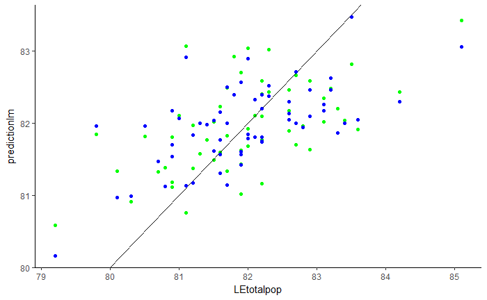

```r
ggplot(data= df_test, aes(x= LEtotalpop, y= predictionlm)) + geom_point(color= "green")+ geom_abline(slope = 1, intercept = 0) + geom_point(data=df_test, aes(x=LEtotalpop, y=predictionrf), color= "blue") +theme_classic()
```